# Lab 4. Factorial Experiments

Daniel Runcie. Modified from labs designed by Iago Hale, Dario Cantu and Jorge Dubcovsky

January 28, 2016

### Specifying contrasts

In the previous labs, we gave you incorrect code for specifying your own contrasts. It worked correctly if your contrasts were orthogonal,but not if they weren’t. This is the correct technique:

```r
contrast_mat <- cbind(
  Ctl_vs_Acid             = c(-3,1,1,1),
  Organic_vs_notOrganic   = c(0,-2,1,1),
  Btwn_organics           = c(0,0,-1,1)
)

# don't worry about what this line does. Just use it before applying any user-defined contrast matrix.
inverse_contrast_mat <- solve(t(cbind(1,contrast_mat)))[,-1]

contrasts(data$Trt) = inverse_contrast_mat
```

Please use this code in the future.

### Specifying linear models in R

We use linear models to calculate ANOVAs, estimate treatment effects, and test contrasts.

`R`’s goal is to provide a lot of flexibility in the types of models that you can specify. But this comes at a cost: you must be careful that you specify **exactly** the model that you want.

A linear model has the general form:

`response ~ explanatory model + error model`

The general form for specifying a linear model in `R` is:

`y ~ 1 + A + B + A:B`

The `terms:` `y`, `A`, and `B` are the names of columns in your `data.frame`. The `~` separates the **response** from the **explanatory model**. The **error model** doesn’t need to be specified (at least for simple experiments!)

`y` is the **response variable** and must be `numeric`. `A` and `B` can be either `numeric` or `factor` (`character` columns are converted to factors automatically). For now, we’ll restrict our study to factors. The model above contains 3 terms: a “main” effect of `A`, a main effect of `B`, and an “interaction” between the levels of `A` and `B`. A model can have as many terms as you want. We have already used models of the form: `y ~ Trt`, where the explanatory model is only the means of each level of `Trt`.

You can tell this model is **linear** because each term is appended with the `+` symbol. We’ll only work with linear models in this class.

Putting this model in the `lm` function like this: `lm(y ~ 1 + A + B + A:B, data)` tells `R` to use the following model for the data: $y_{ijk} = \mu_{11} + \delta^A_{i} + \delta^B_{j} + \delta^{A:B}_{ij} + e_{ijk}$

Each Greek letter represents a **parameter** of the model. The **order** of the parameters is critical for understanding this model.

- The first term is the `(Intercept)`, or the baseline level that everything is compared to. Here, the baseline is the mean of the Treatment specified by the 1st level of `A` and the 1st level of `B`.
- The second term: $\delta^A_{i}$ is the effect of the $ith$ level of `A` relative to the baseline.
- The third term: $\delta^B_{j}$ is the effect of the $jth$ level of `B` relative to the basline.
- The fourth term: $\delta^{A:B}_{ij}$ is the interaction of the $ith$ level of `A` and the $jth$ level of `B`.

The formal definition and **interpretation** of these terms depends on an `attribute` that is assigned to each factor. We’ve worked with these before: By default, `R` chooses to measure deviation among the levels of factors by comparing each level to the 1st. This means that `R` internally runs `contrasts(A) <- contr.treatment`. But you can change this default by running `contrasts(A) <- contr.sum`. If you do this for both `A` and `B`, `R` will fit this model: $y_{ijk} = \mu + \tau^A_{i} + \tau^B_{j} + \tau^{A:B}_{ij} + e_{ijk}$

I’ve used the Greek letter $\tau$ instead of $\delta$ to highlight the fact that these **parameters** are estimate different things, and so should be interpreted differently. $\tau$ represents a treatment deviation from the **global mean** $\mu$. $\delta$ represents a treatment deviation from the 1st mean $\mu_{11}$. Either is a valid measure of treatment deviations. You should choose whichever model best addresses your particular questions.

Here’s a third model to consider:

`lm(y ~ 1 + B + A:B, data)`

What is this model? Let’s assume that we’ve assigned the `contr.sum` contrasts to `A` and `B`: $y_{ijk} = \mu + \tau^B_{j} + \gamma^{A:B}_{ij} + e_{ijk}$

This looks similar, except there is no main effect term for `A`. Instead I’ve replaced $\tau^A_{i} + \tau^{A:B}_{ij}$ with $\gamma^{A:B}_{ij}$. Why? Once we know that there is an interaction, we often want to estimate the effect of Factor `A` in each level of Factor `B`. The term $\gamma^{A:B}_{ij}$ measures the whole effect of `A` in each level of `B`, not just the non-additive deviation.

### Shortcuts

R allows several shortcuts in writing models:

- The `1` signifying a non-zero intercept for comparing all treatments can be ommited. It’s assumed to be there unless you replace it with a `0` meaning the intercept should be fixed to 0.
- `A + B + A:B` can be shortened to `A*B`
- `(A + B)^2` also means `A + B + A:B`
- `(A + B + C)^2` means all pairwise interactions, but no 3-way: `A + B + C + A:B + A:C + B:C`

We can create our own terms by forming new labels: `A_B = interaction(A,B)`. `lm(y ~ A + B + A_B)`

Each term that you write in your model separated by the `+` symbol (except the `1`) will get it’s own row in the ANOVA table.

**With that, lets run an example**

### Example 1

In a study comparing the relative growth of five varieties of mustard (VAR) in three experimental soil mixtures (SOIL), six pots were prepared with each VAR-SOIL combination. The 90 pots were randomly placed in a greenhouse and cumulative yields were measured. The main interest in this experiment is identifying which soil is best for each variety of mustard, and testing if the effects of different soils change among the varieties.

```r
mustard_data <- read.csv('Mustard_soil.csv')
str(mustard_data)
```

```
## 'data.frame':    90 obs. of  3 variables:
##  $ Soil : int  1 1 1 1 1 2 2 2 2 2 ...
##  $ Var  : int  1 2 3 4 5 1 2 3 4 5 ...
##  $ Yield: num  22.1 27.1 22.3 19.8 20 13.5 16.9 15.7 15.1 21.8 ...
```

Make `Soil` and `Var` factors

```r
mustard_data$Soil = factor(mustard_data$Soil)
mustard_data$Var = factor(mustard_data$Var)
```

#### Step 1: Check model assumptions

To test the model assumptions, it’s easiest to fit a simple one-way model with each Treatment coded separately:

```r
# Make a new variable for Treatment that has a separate level for each combination of Soil and Var
mustard_data$Trt = interaction(mustard_data$Soil,mustard_data$Var)
summary(mustard_data)
```

```
##  Soil   Var        Yield            Trt
##  1:30   1:18   Min.   : 6.00   1.1    : 6
##  2:30   2:18   1st Qu.:14.65   2.1    : 6
##  3:30   3:18   Median :18.55   3.1    : 6
##         4:18   Mean   :18.44   1.2    : 6
##         5:18   3rd Qu.:22.10   2.2    : 6
##                Max.   :28.60   3.2    : 6
##                                (Other):54
```

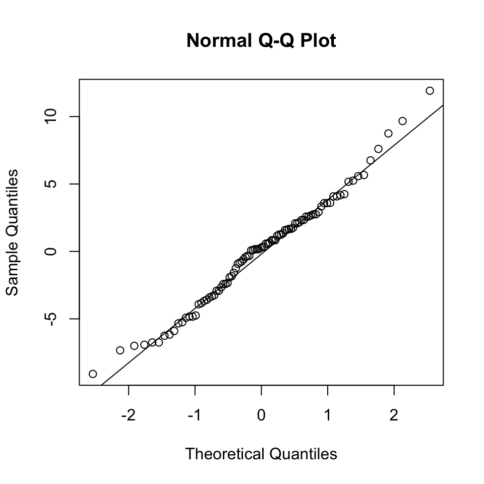

```r
# Fit this model and extract residuals
TRT_model <- lm(Yield ~ Trt, mustard_data)
residuals <- resid(TRT_model)

# Make a qqnorm plot of the residuals
qqnorm(residuals)
qqline(residuals)
```

```r
# Do a shapiro test on the joint residuals
shapiro.test(residuals)
```

```
##
##  Shapiro-Wilk normality test
##
## data:  residuals
## W = 0.98643, p-value = 0.4772
```

```r
# Do a Levene's Test on the model
library(car)
leveneTest(TRT_model)
```

```
## Levene's Test for Homogeneity of Variance (center = median)
##       Df F value Pr(>F)
## group 14  0.8767 0.5862
##       75
```

### Step 2: Specify the linear model for the factorial

```r
mustard_model <- lm(Yield ~ 1 + Soil + Var + Soil:Var,mustard_data)

# Note: we could have done: it's the same
mustard_model <- lm(Yield ~ Soil * Var,mustard_data)
```

But wait! Which model did we fit? Since we didn’t specify any contrasts for the `Soil` and `Var` factors, `R` assumes we want to compare all levels to the first level. Which is that?

```r
levels(mustard_data$Soil)
```

```
## [1] "1" "2" "3"
```

```r
levels(mustard_data$Var)
```

```
## [1] "1" "2" "3" "4" "5"
```

So, we’re comparing to Soil 1 and Var 1. Is that reasonable? Let’s switch and use the **sum-to-zero** parameterization:

```r
contrasts(mustard_data$Soil) = contr.sum
contrasts(mustard_data$Var) = contr.sum

# re-fit the model
mustard_model_sumContrasts <- lm(Yield ~ Soil * Var,mustard_data)
```

### Step 3: Run an ANOVA to test for `Soil:Var` interactions

```r
anova(mustard_model_sumContrasts)
```

```
## Analysis of Variance Table
##
## Response: Yield
##           Df  Sum Sq Mean Sq F value    Pr(>F)
## Soil       2  953.16  476.58 24.2531 7.525e-09 ***
## Var        4   11.38    2.85  0.1448   0.96476
## Soil:Var   8  374.49   46.81  2.3822   0.02409 *
## Residuals 75 1473.77   19.65
## ---
## Signif. codes:  0 '***' 0.001 '**' 0.01 '*' 0.05 '.' 0.1 ' ' 1
```

Several things to note:

- The degrees of freedom for the three treatment rows sum to 14. The total number of treatments was 3x5 = 15. Does this make sense?
- The `Soil:Var` term is significant. Therefore we have an interaction
- The `Sum Sq` for `Soil` itself is about 3x that of the `Soil:Var` row. This means that there is quite a bit of soil-type variation overall (main effect) with only some more-minor modification of those effects for each Variety

It can be very helpful to visualize what’s going on. The best way to do this is with the `ggplot2` package:

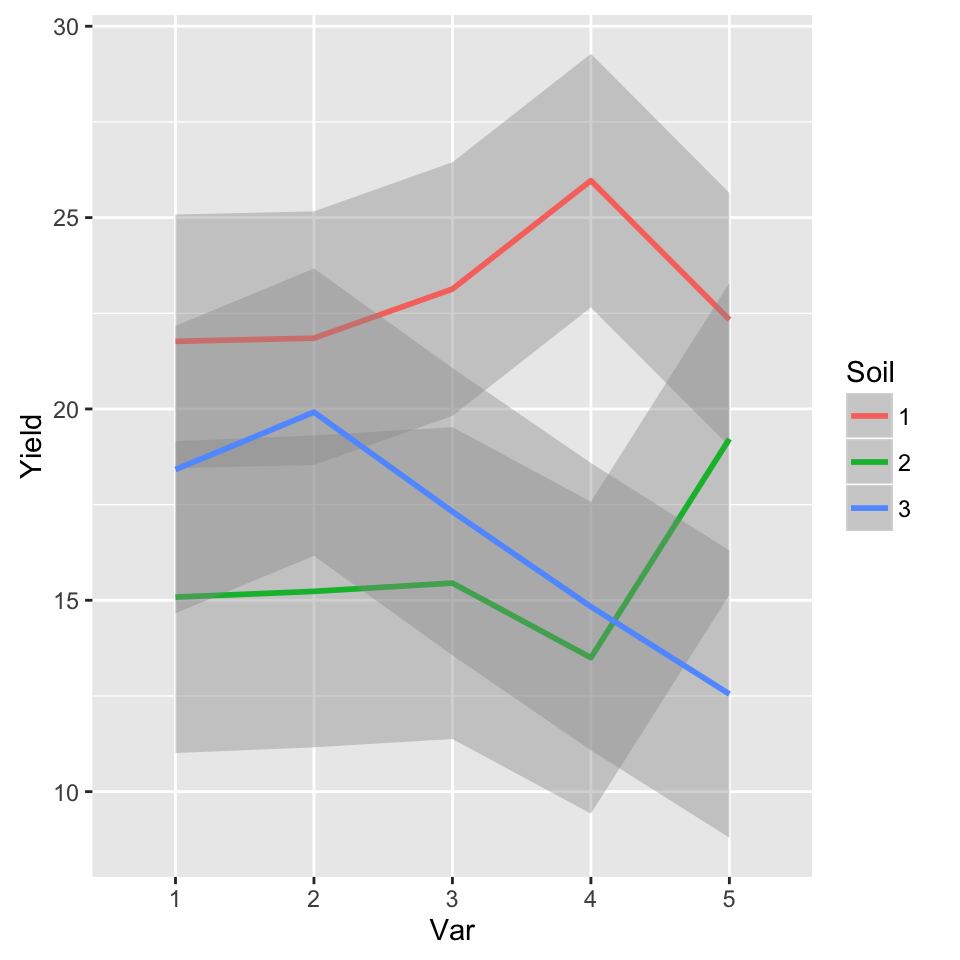

```r
# install.packages('ggplot2') # only if you haven't done this before.
library(ggplot2)
ggplot(mustard_data,aes(x=Var,y=Yield,group=Soil)) +
    geom_smooth(aes(color=Soil),method='lm',formula = y~factor(x))
```

This is an interaction plot. Non-parallel lines show an interaction. We see that Soil 1 produces the highest yields for each Variety, but the differences among soils do change across varieties. We make these formal statements with the ANOVA, but this plot really shows you what is going on.

We could (equivalently) inspect the change in the yield of each mustard variety in each soil type:

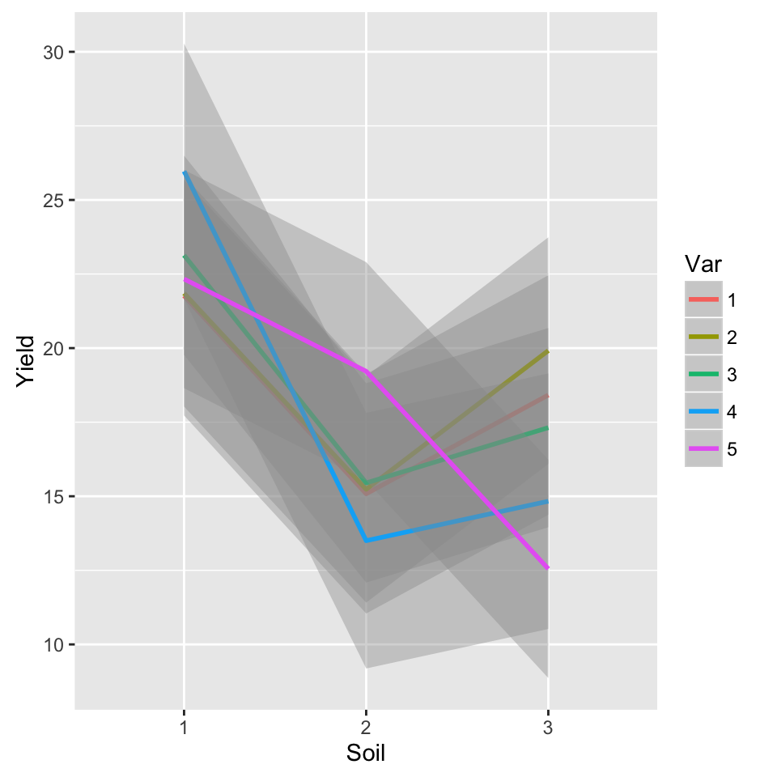

```r
ggplot(mustard_data,aes(x=Soil,y=Yield,group=Var)) +
    geom_smooth(aes(color=Var),method='lm',formula = y~factor(x))
```

### Step 4. Now that we know that there is an interaction, we should report on the effect on Yield for each Soil for each Variety.

The easiest way to do this is to fit a new model:

```r
soil_effects_by_Var <- lm(Yield ~ Var + Soil:Var,mustard_data)
```

The `summary` function gives you direct access to the parameter values:

```r
summary(soil_effects_by_Var)
```

```
##
## Call:
## lm(formula = Yield ~ Var + Soil:Var, data = mustard_data)
##
## Residuals:
##     Min      1Q  Median      3Q     Max
## -9.0833 -2.9167  0.2917  2.5208 11.9167
##
## Coefficients:
##             Estimate Std. Error t value Pr(>|t|)
## (Intercept) 18.43778    0.46726  39.459  < 2e-16 ***
## Var1        -0.01556    0.93453  -0.017  0.98676
## Var2         0.56222    0.93453   0.602  0.54925
## Var3         0.19556    0.93453   0.209  0.83482
## Var4        -0.33778    0.93453  -0.361  0.71879
## Var1:Soil1   3.34444    1.47762   2.263  0.02650 *
## Var2:Soil1   2.85000    1.47762   1.929  0.05754 .
## Var3:Soil1   4.50000    1.47762   3.045  0.00320 **
## Var4:Soil1   7.86667    1.47762   5.324 1.02e-06 ***
## Var5:Soil1   4.30000    1.47762   2.910  0.00475 **
## Var1:Soil2  -3.33889    1.47762  -2.260  0.02675 *
## Var2:Soil2  -3.76667    1.47762  -2.549  0.01284 *
## Var3:Soil2  -3.18333    1.47762  -2.154  0.03442 *
## Var4:Soil2  -4.60000    1.47762  -3.113  0.00262 **
## Var5:Soil2   1.18333    1.47762   0.801  0.42576
## ---
## Signif. codes:  0 '***' 0.001 '**' 0.01 '*' 0.05 '.' 0.1 ' ' 1
##
## Residual standard error: 4.433 on 75 degrees of freedom
## Multiple R-squared:  0.476,  Adjusted R-squared:  0.3782
## F-statistic: 4.867 on 14 and 75 DF,  p-value: 2.723e-06
```

Here is where it’s critical to know what contrasts were assigned to each treatment. Because we used the `contr.sum` contrasts, our model is: $y_{ijk} = \mu + \tau^B_{j} + \gamma^{A:B}_{ij} + e_{ijk}$ So are parameters are the $\tau^B_{j}$ and $\gamma^{A:B}_{ij}$ values. `R` gives us all of these, except the ones that were constrained to be zero.

> Compare these values to the figure. Do they line up? Can you find which parameters are missing?

From the `summary` output, we can extract the effects of Soil on each Variety, plus the differences among Varieties (on average across the soil types). We also get estimates of the standard error. This is actually exactly what `ggplot2` is showing us in the figure above (the grey regions).

With the standard errors, we can create confidence intervals for each Soil:Var effect. The formula for a confidence interval is: $\gamma^{A:B}_{ij} \pm t_{1-\alpha/2,Df}*SE$

But wait! What $\alpha$ should we use? Since we have 10 estimates, we should correct $\alpha$ for the 10 tests so that our intervals have **simultaneous $100(1-\alpha)$ coverage**

This is all fine, as long as we’re content to report only the difference between Soil 1 and the global mean and the difference between Soil 2 and the global mean. But what if we want to directly compare Soils 1 and 2 for each Variety? This means making all pair-wise comparison among the three soils for each Variety. We can use the Tukey test to do this.

The following is somewhat complicated, but try to follow. For any assignments that ask for this, you should be able to copy the following code and just modify the names of variables.

1. So far, we’ve fit a single model `mustard_model_sumContrasts` that compares all treatments.
2. If you send this whole model to the `HSD.test` function, it will compare all pairs of treatments. That’s 15*(15-1)/2 pairwise tests.
3. But we don’t want to make all those tests. We only want to make the 3 pairwise comparisons within each of the 5 varieties
4. So, we can break up the data into 5 subsets (1 for each variety) and use `HSD.test` to compare the three soils in each subset.
5. Since we’re running 5 Tukey analyses, we want to control the overall EER by modifying the $\alpha$ parameter for `HSD.test`
6. This would be fine to do. But when we fit all the data together, we were able to use a single pooled estimate of the within-group error. We should be able to do that here too.
7. This is how to put it all together:

```r
library(agricolae)

# First from the overall ANOVA, extract the MSE estimate and residual Df
mustard_anova = anova(mustard_model_sumContrasts)
DFerror = mustard_anova['Residuals',"Df"]
MSerror = mustard_anova['Residuals',"Mean Sq"]

# Now, calculate an adjusted alpha based on the 5 Tuke tests you'll run:
alpha_group = 1-(1-0.05)^(1/5)

# Now for each variety,
#   1. subset the data to include only 1 Variety's data
#   2. Then pass the Yield and Soil columns to the HSD.test function

with(subset(mustard_data,Var==1),
     HSD.test(Yield,Soil,DFerror=DFerror,MSerror = MSerror, alpha = alpha_group)$groups)
```

```
##   trt    means M
## 1   1 21.76667 a
## 2   3 18.41667 a
## 3   2 15.08333 a
```

```r
with(subset(mustard_data,Var==2),
     HSD.test(Yield,Soil,DFerror=DFerror,MSerror = MSerror, alpha = alpha_group)$groups)
```

```
##   trt    means M
## 1   1 21.85000 a
## 2   3 19.91667 a
## 3   2 15.23333 a
```

```r
with(subset(mustard_data,Var==3),
     HSD.test(Yield,Soil,DFerror=DFerror,MSerror = MSerror, alpha = alpha_group)$groups)
```

```
##   trt    means  M
## 1   1 23.13333  a
## 2   3 17.31667 ab
## 3   2 15.45000  b
```

```r
with(subset(mustard_data,Var==4),
     HSD.test(Yield,Soil,DFerror=DFerror,MSerror = MSerror, alpha = alpha_group)$groups)
```

```
##   trt    means M
## 1   1 25.96667 a
## 2   3 14.83333 b
## 3   2 13.50000 b
```

```r
with(subset(mustard_data,Var==5),
     HSD.test(Yield,Soil,DFerror=DFerror,MSerror = MSerror, alpha = alpha_group)$groups)
```

```
##   trt    means  M
## 1   1 22.33333  a
## 2   2 19.21667 ab
## 3   3 12.55000  b
```

```r
# If you want to save these answers in a table, you could do the following. I've noted how to modify the code for your own data.
list_of_vars = levels(mustard_data$Var)  # Change this line for your data and variable to partion on
tukey_table = sapply(list_of_vars,function(var){
  with(
    subset(mustard_data,Var==var), {  # modify this line by replacing `mustard_data` with your data, and `Var` with your partitioning factor
     groups = HSD.test(
                        Yield, # modify this with your response variable
                        Soil,  # modify this with your factor of interest
                        DFerror=DFerror,MSerror = MSerror, alpha = alpha_group)$groups
     groups = groups[order(groups$trt),]
     groups$M
    })
})
colnames(tukey_table) = paste('Var',1:5)
rownames(tukey_table) = paste('Soil',1:3)
tukey_table
```

```
##        Var 1 Var 2 Var 3 Var 4 Var 5
## Soil 1 "a"   "a"   "a"   "a"   "a"
## Soil 2 "a"   "a"   "b"   "b"   "ab"
## Soil 3 "a"   "a"   "ab"  "b"   "b"
```

> Do these results make sense compared to the interaction plot?

### Some final notes:

We first fit the model using the default `contr.treatment` contrasts. The ANOVA table for that model is identical to the one with the `contr.sum` contrasts:

```r
anova(mustard_model)
```

```
## Analysis of Variance Table
##
## Response: Yield
##           Df  Sum Sq Mean Sq F value    Pr(>F)
## Soil       2  953.16  476.58 24.2531 7.525e-09 ***
## Var        4   11.38    2.85  0.1448   0.96476
## Soil:Var   8  374.49   46.81  2.3822   0.02409 *
## Residuals 75 1473.77   19.65
## ---
## Signif. codes:  0 '***' 0.001 '**' 0.01 '*' 0.05 '.' 0.1 ' ' 1
```

```r
anova(mustard_model_sumContrasts)
```

```
## Analysis of Variance Table
##
## Response: Yield
##           Df  Sum Sq Mean Sq F value    Pr(>F)
## Soil       2  953.16  476.58 24.2531 7.525e-09 ***
## Var        4   11.38    2.85  0.1448   0.96476
## Soil:Var   8  374.49   46.81  2.3822   0.02409 *
## Residuals 75 1473.77   19.65
## ---
## Signif. codes:  0 '***' 0.001 '**' 0.01 '*' 0.05 '.' 0.1 ' ' 1
```

But, the `summary` tables are different because the models have different **parameters** ($\delta$ vs $\tau$)

```r
summary(mustard_model)
```

```
##
## Call:
## lm(formula = Yield ~ Soil * Var, data = mustard_data)
##
## Residuals:
##     Min      1Q  Median      3Q     Max
## -9.0833 -2.9167  0.2917  2.5208 11.9167
##
## Coefficients:
##             Estimate Std. Error t value Pr(>|t|)
## (Intercept) 21.76667    1.80971  12.028   <2e-16 ***
## Soil2       -6.68333    2.55931  -2.611   0.0109 *
## Soil3       -3.35000    2.55931  -1.309   0.1945
## Var2         0.08333    2.55931   0.033   0.9741
## Var3         1.36667    2.55931   0.534   0.5949
## Var4         4.20000    2.55931   1.641   0.1050
## Var5         0.56667    2.55931   0.221   0.8254
## Soil2:Var2   0.06667    3.61941   0.018   0.9854
## Soil3:Var2   1.41667    3.61941   0.391   0.6966
## Soil2:Var3  -1.00000    3.61941  -0.276   0.7831
## Soil3:Var3  -2.46667    3.61941  -0.682   0.4976
## Soil2:Var4  -5.78333    3.61941  -1.598   0.1143
## Soil3:Var4  -7.78333    3.61941  -2.150   0.0347 *
## Soil2:Var5   3.56667    3.61941   0.985   0.3276
## Soil3:Var5  -6.43333    3.61941  -1.777   0.0795 .
## ---
## Signif. codes:  0 '***' 0.001 '**' 0.01 '*' 0.05 '.' 0.1 ' ' 1
##
## Residual standard error: 4.433 on 75 degrees of freedom
## Multiple R-squared:  0.476,  Adjusted R-squared:  0.3782
## F-statistic: 4.867 on 14 and 75 DF,  p-value: 2.723e-06
```

```r
summary(mustard_model_sumContrasts)
```

```
##
## Call:
## lm(formula = Yield ~ Soil * Var, data = mustard_data)
##
## Residuals:
##     Min      1Q  Median      3Q     Max
## -9.0833 -2.9167  0.2917  2.5208 11.9167
##
## Coefficients:
##             Estimate Std. Error t value Pr(>|t|)
## (Intercept) 18.43778    0.46726  39.459  < 2e-16 ***
## Soil1        4.57222    0.66081   6.919 1.32e-09 ***
## Soil2       -2.74111    0.66081  -4.148 8.75e-05 ***
## Var1        -0.01556    0.93453  -0.017   0.9868
## Var2         0.56222    0.93453   0.602   0.5492
## Var3         0.19556    0.93453   0.209   0.8348
## Var4        -0.33778    0.93453  -0.361   0.7188
## Soil1:Var1  -1.22778    1.32162  -0.929   0.3559
## Soil2:Var1  -0.59778    1.32162  -0.452   0.6524
## Soil1:Var2  -1.72222    1.32162  -1.303   0.1965
## Soil2:Var2  -1.02556    1.32162  -0.776   0.4402
## Soil1:Var3  -0.07222    1.32162  -0.055   0.9566
## Soil2:Var3  -0.44222    1.32162  -0.335   0.7389
## Soil1:Var4   3.29444    1.32162   2.493   0.0149 *
## Soil2:Var4  -1.85889    1.32162  -1.407   0.1637
## ---
## Signif. codes:  0 '***' 0.001 '**' 0.01 '*' 0.05 '.' 0.1 ' ' 1
##
## Residual standard error: 4.433 on 75 degrees of freedom
## Multiple R-squared:  0.476,  Adjusted R-squared:  0.3782
## F-statistic: 4.867 on 14 and 75 DF,  p-value: 2.723e-06
```

> Spend some time with these two tables until you really understand what each parameter means.

Finally, lets compare our factorial ANOVA with the one-way ANOVA we get when combining all treatments into the same Factor:

```r
anova(TRT_model)
```

```
## Analysis of Variance Table
##
## Response: Yield
##           Df Sum Sq Mean Sq F value    Pr(>F)
## Trt       14 1339.0  95.645  4.8674 2.723e-06 ***
## Residuals 75 1473.8  19.650
## ---
## Signif. codes:  0 '***' 0.001 '**' 0.01 '*' 0.05 '.' 0.1 ' ' 1
```

```r
anova(mustard_model_sumContrasts)
```

```
## Analysis of Variance Table
##
## Response: Yield
##           Df  Sum Sq Mean Sq F value    Pr(>F)
## Soil       2  953.16  476.58 24.2531 7.525e-09 ***
## Var        4   11.38    2.85  0.1448   0.96476
## Soil:Var   8  374.49   46.81  2.3822   0.02409 *
## Residuals 75 1473.77   19.65
## ---
## Signif. codes:  0 '***' 0.001 '**' 0.01 '*' 0.05 '.' 0.1 ' ' 1
```

Three things:

- The Residuals lines are identical
- The Df of Trt is the sum of the Df of Soil, Var, and Soil:Var
- The Sum Sq numbers also sum to the same

That’s because what we’ve done with the factorial ANOVA is to break up the Trt term into three separate tests so that we could interpret each group separately. But we haven’t fundamentally changed the underlying model at all.

## Example 2

In this example, I want to compare **contrasts** and **linear models**.

> **Note**: In previous labs, I provided INCORRECT code for assigning contrasts to treatments. Below I provide the correct code

For this, let’s simplify the above data taking only two varieties and two soils:

```r
small_data = droplevels(subset(mustard_data,Soil %in% c(1,2) & Var %in% c(2,4)))
summary(small_data)
```

```
##  Soil   Var        Yield        Trt
##  1:12   2:12   Min.   : 6.50   1.2:6
##  2:12   4:12   1st Qu.:15.10   2.2:6
##                Median :18.40   1.4:6
##                Mean   :19.14   2.4:6
##                3rd Qu.:26.80
##                Max.   :28.60
```

Let’s quickly run a factorial ANOVA:

```r
small_lm = lm(Yield ~ Soil*Var,small_data)
anova(small_lm)
```

```
## Analysis of Variance Table
##
## Response: Yield
##           Df Sum Sq Mean Sq F value    Pr(>F)
## Soil       1 546.26  546.26 24.9924 6.885e-05 ***
## Var        1   8.52    8.52  0.3898    0.5394
## Soil:Var   1  51.33   51.33  2.3486    0.1411
## Residuals 20 437.14   21.86
## ---
## Signif. codes:  0 '***' 0.001 '**' 0.01 '*' 0.05 '.' 0.1 ' ' 1
```

This time the interaction is not significant. This means we’d like to report the average effect of Soil and average effect of Var. We can get this from the `summary` table, ignoring the `Soil2:Var4` term:

```r
summary(small_lm)
```

```
##
## Call:
## lm(formula = Yield ~ Soil * Var, data = small_data)
##
## Residuals:
##     Min      1Q  Median      3Q     Max
## -7.0000 -3.7083  0.8333  2.4375  7.6000
##
## Coefficients:
##             Estimate Std. Error t value Pr(>|t|)
## (Intercept)   21.850      1.909  11.448 3.11e-10 ***
## Soil2         -6.617      2.699  -2.451   0.0236 *
## Var4           4.117      2.699   1.525   0.1429
## Soil2:Var4    -5.850      3.817  -1.533   0.1411
## ---
## Signif. codes:  0 '***' 0.001 '**' 0.01 '*' 0.05 '.' 0.1 ' ' 1
##
## Residual standard error: 4.675 on 20 degrees of freedom
## Multiple R-squared:  0.581,  Adjusted R-squared:  0.5181
## F-statistic: 9.244 on 3 and 20 DF,  p-value: 0.0004856
```

Now, let’s make the same comparison with contrasts. We want to make the following contrasts:

```r
contrast_matrix <- cbind(
  S2_S1_inV2 = c(-1,1,0,0),
  S2_S1_inV2_minus_S2_S1_inV4 = c(-1,1,1,-1),
  V4_V2_in_S1 = c(-1,0,1,0)
)
rownames(contrast_matrix) = levels(small_data$Trt)
contrast_matrix
```

```
##     S2_S1_inV2 S2_S1_inV2_minus_S2_S1_inV4 V4_V2_in_S1
## 1.2         -1                          -1          -1
## 2.2          1                           1           0
## 1.4          0                           1           1
## 2.4          0                          -1           0
```

1. Are these orthogonal contrasts?
2. Can you tell how each asks one of the questions that we want?

**There was a mistake in how we assigned a contrast matrix to a factor in previous Labs!!!** The correct way is below:

```r
inverse_contrast_matrix = solve(t(cbind(1,contrast_matrix)))[,-1]
contrasts(small_data$Trt) = inverse_contrast_matrix
```

Now, fit a new model for Trt:

```r
contrast_model <- lm(Yield ~ Trt,small_data)
```

The ANOVA didn’t change:

```r
anova(contrast_model)
```

```
## Analysis of Variance Table
##
## Response: Yield
##           Df Sum Sq Mean Sq F value    Pr(>F)
## Trt        3 606.11 202.038  9.2436 0.0004856 ***
## Residuals 20 437.14  21.857
## ---
## Signif. codes:  0 '***' 0.001 '**' 0.01 '*' 0.05 '.' 0.1 ' ' 1
```

Now, `summary` gives us the correct contrasts

```r
summary(contrast_model)
```

```
##
## Call:
## lm(formula = Yield ~ Trt, data = small_data)
##
## Residuals:
##     Min      1Q  Median      3Q     Max
## -7.0000 -3.7083  0.8333  2.4375  7.6000
##
## Coefficients:
##                                Estimate Std. Error t value Pr(>|t|)
## (Intercept)                     19.1375     0.9543  20.054 1.03e-14 ***
## TrtS2_S1_inV2                   -6.6167     2.6992  -2.451   0.0236 *
## TrtS2_S1_inV2_minus_S2_S1_inV4   5.8500     3.8172   1.533   0.1411
## TrtV4_V2_in_S1                   4.1167     2.6992   1.525   0.1429
## ---
## Signif. codes:  0 '***' 0.001 '**' 0.01 '*' 0.05 '.' 0.1 ' ' 1
##
## Residual standard error: 4.675 on 20 degrees of freedom
## Multiple R-squared:  0.581,  Adjusted R-squared:  0.5181
## F-statistic: 9.244 on 3 and 20 DF,  p-value: 0.0004856
```

To verify this, manually calculate the contrasts using the following treatment means:

```r
aggregate(small_data$Yield,list(small_data$Trt),mean)
```

```
##   Group.1        x
## 1     1.2 21.85000
## 2     2.2 15.23333
## 3     1.4 25.96667
## 4     2.4 13.50000
```

We can actually get `R` to give us these values using the model formula instead:

```r
contrasts(small_data$Var) = contr.treatment
contrasts(small_data$Soil) = contr.treatment
small_lm2 <- lm(Yield ~ Var + Soil + Soil:Var,small_data)
summary(small_lm2)
```

```
##
## Call:
## lm(formula = Yield ~ Var + Soil + Soil:Var, data = small_data)
##
## Residuals:
##     Min      1Q  Median      3Q     Max
## -7.0000 -3.7083  0.8333  2.4375  7.6000
##
## Coefficients:
##             Estimate Std. Error t value Pr(>|t|)
## (Intercept)   21.850      1.909  11.448 3.11e-10 ***
## Var2           4.117      2.699   1.525   0.1429
## Soil2         -6.617      2.699  -2.451   0.0236 *
## Var2:Soil2    -5.850      3.817  -1.533   0.1411
## ---
## Signif. codes:  0 '***' 0.001 '**' 0.01 '*' 0.05 '.' 0.1 ' ' 1
##
## Residual standard error: 4.675 on 20 degrees of freedom
## Multiple R-squared:  0.581,  Adjusted R-squared:  0.5181
## F-statistic: 9.244 on 3 and 20 DF,  p-value: 0.0004856
```

```r
summary(contrast_model)
```

```
##
## Call:
## lm(formula = Yield ~ Trt, data = small_data)
##
## Residuals:
##     Min      1Q  Median      3Q     Max
## -7.0000 -3.7083  0.8333  2.4375  7.6000
##
## Coefficients:
##                                Estimate Std. Error t value Pr(>|t|)
## (Intercept)                     19.1375     0.9543  20.054 1.03e-14 ***
## TrtS2_S1_inV2                   -6.6167     2.6992  -2.451   0.0236 *
## TrtS2_S1_inV2_minus_S2_S1_inV4   5.8500     3.8172   1.533   0.1411
## TrtV4_V2_in_S1                   4.1167     2.6992   1.525   0.1429
## ---
## Signif. codes:  0 '***' 0.001 '**' 0.01 '*' 0.05 '.' 0.1 ' ' 1
##
## Residual standard error: 4.675 on 20 degrees of freedom
## Multiple R-squared:  0.581,  Adjusted R-squared:  0.5181
## F-statistic: 9.244 on 3 and 20 DF,  p-value: 0.0004856
```

Carefully using the model formulas can give you access to the same **estimates** as you can get with **contrasts**, but it’s often a lot easier.